# A: Time series

# Background information

Aim to peak emissions at 65 million tons of CO2 equivalent (MtCO2e) around 2030 and halve our emissions from its peak to 33 MtCO2e by 2050, with a view to achieving net zero emissions as soon as viable in the second half of the century.

```python
import pandas as pd
import numpy as np
import matplotlib.pyplot as plt
import seaborn as sns

df = pd.read_csv('Energy Consumption Dataset.csv',sep=',')

df.describe()

#drop duplicates
df.drop_duplicates()

#check for missing values
print("--Missing values--")
print(df.isnull().sum(),'\n')

df.info()
```

```
--Missing values--
DATE                             0
Gas Consumption (tons)           0
Electricity Consumption (MWh)    0
Water Consumption (tons)         0
dtype: int64

<class 'pandas.core.frame.DataFrame'>
RangeIndex: 397 entries, 0 to 396
Data columns (total 4 columns):
 #   Column                         Non-Null Count  Dtype
---  ------                         --------------  -----
 0   DATE                           397 non-null    object
 1   Gas Consumption (tons)         397 non-null    float64
 2   Electricity Consumption (MWh)  397 non-null    float64
 3   Water Consumption (tons)       397 non-null    float64
dtypes: float64(3), object(1)
memory usage: 12.5+ KB
```

```python
df.describe()
```

|  | Gas Consumption (tons) | Electricity Consumption (MWh) | Water Consumption (tons) |
| --- | --- | --- | --- |
| count | 397.000000 | 397.000000 | 397.000000 |
| mean | 23.785139 | 888.472544 | 484.953652 |
| std | 4.903452 | 153.877594 | 133.908863 |
| min | 11.600000 | 553.200000 | 44.400000 |
| 25% | 20.200000 | 771.100000 | 384.400000 |
| 50% | 23.500000 | 897.800000 | 487.400000 |
| 75% | 27.900000 | 1005.200000 | 580.200000 |
| max | 46.000000 | 1294.000000 | 811.000000 |

```python
df[["Day", "Month", "Year"]] = df["DATE"].str.split("/", expand = True)
```

As the 'Date' column datatype is 'Object', we are going to convert it to 'datetime'

```python
df["DATE"] = pd.to_datetime(df["DATE"],format='%d/%m/%Y')
```

```python
#set the index of pandas dataframe 'df' to the 'date' column so that it will act as x-axis
df.set_index('DATE', inplace=True)
```

```python
df= df.asfreq('MS')
```

# Data exploration

```python
import warnings
warnings.simplefilter("ignore")

from warnings import simplefilter
from sklearn.exceptions import ConvergenceWarning
```

```python
#finding a subset

res = df[pd.Timestamp('2022-01-01'):pd.Timestamp('2022-12-01')]
```

```python
# Calculate the percentage change in electricity consumption
res['%Change (electricity)'] = df['Electricity Consumption (MWh)'].pct_change() * 100
res['%Change (gas)'] = df['Gas Consumption (tons)'].pct_change() * 100
res['%Change (water)'] = df['Water Consumption (tons)'].pct_change() * 100
```

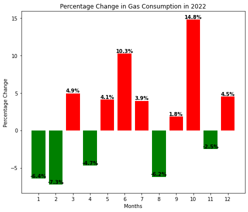

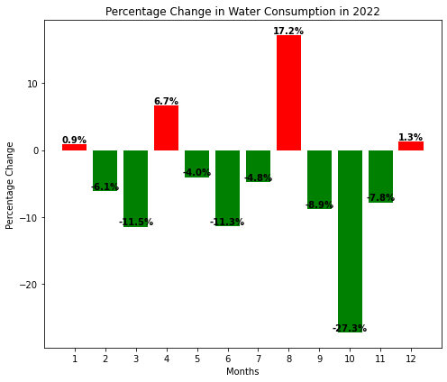

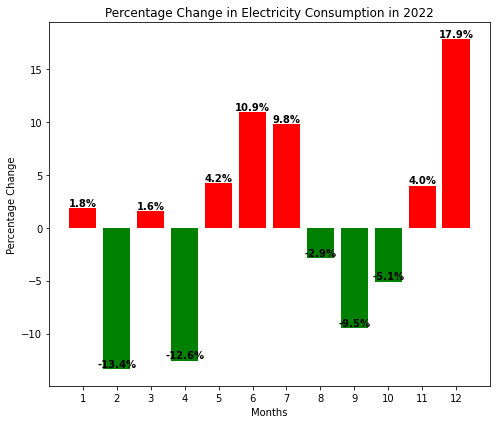

```python
def plot_percentage_change_bar(title,consumption):
    # Plot the bar graph
    plt.figure(figsize=(7, 6))
    plt.bar(res['Month'], res[consumption], color=res[consumption].apply(lambda x: 'red' if x > 0 else 'green'))

    # Add labels and title
    plt.xlabel('Months')
    plt.ylabel('Percentage Change')
    plt.title(title)

    # Add percentage values above bars
    for i, v in enumerate(res[consumption]):
        plt.text(i, v, f"{v:.1f}%", ha='center', va='bottom', fontweight='bold')

    plt.tight_layout()
    plt.show()

# Assuming you have separate resFrames for gas, water, and electricity consumption changes
# gas_res, water_res, electricity_res are assumed to be resFrames with columns 'Month' and '%Change (gas)', '%Change (water)', '%Change (electricity)' respectively.

plot_percentage_change_bar('Percentage Change in Gas Consumption in 2022', '%Change (gas)')
plot_percentage_change_bar('Percentage Change in Water Consumption in 2022', '%Change (water)')
plot_percentage_change_bar('Percentage Change in Electricity Consumption in 2022', '%Change (electricity)')
```

Generally there are more occurance of increase in consumption for gas and electricity especially during the period between May and July whereas for water there are more dips in consumption in periods of 3 consecutively months.

The increase in gas and electricity consumption during May to July might due to more people switiching on the air-conditioner in higher temperatures during these months.

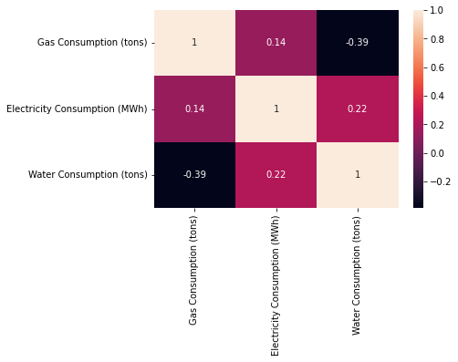

```python
#plot heatmap

sns.heatmap(df.corr(),annot=True)
```

1. Weak correlation of below 0.5 between the consumptions.
2. The consumptions are independent of each other.

```python
#for easier use
gas = df['Gas Consumption (tons)']
electricity = df['Electricity Consumption (MWh)']
water = df['Water Consumption (tons)']
```

[figure not shown]

```python
# Create three separate subplots side by side
fig, (ax1, ax2, ax3) = plt.subplots(1, 3, figsize=(15, 5))

# Plot Water Consumption
color1 = 'tab:red'
ax1.plot(water.index, water, label="Water Consumption (tons)", linestyle="-", color=color1)
ax1.set_ylabel("Water (tons)")
ax1.set_title("Water Consumption")
plt.xlabel("Year")

# Plot Electricity Consumption
color2 = 'tab:orange'
ax2.plot(electricity.index, electricity, label="Electricity Consumption (MWh)", linestyle="-", color=color2)
ax2.set_ylabel("Electricity Consumption (MWh)")
ax2.set_title("Electricity Consumption")
plt.xlabel("Year")

# Plot Gas Consumption
ax3.plot(gas.index, gas, label="Gas Consumption (tons)", linestyle="-")
ax3.set_ylabel("Gas Consumption (tons)")
ax3.set_title("Gas Consumption")

# Adjust layout and legend
plt.xlabel("Year")
plt.suptitle("Mean Consumption")
plt.tight_layout()
plt.show()
```

Electricity consumption has a steady increasing linear relationship as the years increase

And Water and gas consumption has many fluctuations but has the same frequency (width of cycles) and amplitude (height of cycles) which is displayed by our graphs.

Hence they are additive models- linear where changes over time are consistently made by the same amount.

# Stationary check

```python
# Augmented Dickey-Fuller Test
from statsmodels.tsa.stattools import adfuller
def fuller(col):
    result1 = adfuller(df[col])
    return print(col,'p-value is ',result1[1])

# print('Gas consumption p-value:',result1[1])

fuller('Gas Consumption (tons)')
fuller('Electricity Consumption (MWh)')
fuller('Water Consumption (tons)')
```

```
Gas Consumption (tons) p-value is  0.01081065170706051
Electricity Consumption (MWh) p-value is  0.18621802300336632
Water Consumption (tons) p-value is  8.984549388336973e-05
```

P-value <= 0.05: Reject the null hypothesis (H0), the gas and water data does not have a unit root and is stationary.

P-value > 0.05: Fail to reject the null hypothesis (H0), the electricity has a unit root and is non-stationary

# Differencing

Differencing technique helps to remove the trend and seasonality from time series data by subtracting the current value from the previous to transform series into stationarity

```python
#for electricity
```

[output not shown]

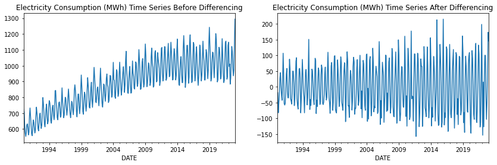

```python
from statsmodels.tsa.statespace.tools import diff
# perform differencing operation

df_diff = electricity.diff(periods=1)

# Perform Augmented Dickey-Fuller test on the original and differenced time series
resultt = adfuller(electricity)
result2 = adfuller(df_diff.dropna())  # Drop the first two NaN values due to differencing

# Print p-values
print('Electricity Consumption (MWh) before differencing p-value: %f' % resultt[1])
print('Electricity Consumption (MWh) after differencing p-value: %f' % result2[1])

# Plot the original time series and the differenced time series side by side
fig, ax = plt.subplots(1, 2, figsize=(14, 4))
electricity.plot(ax=ax[0])
df_diff.plot(ax=ax[1])
ax[0].set_title('Electricity Consumption (MWh) Time Series Before Differencing')
ax[1].set_title('Electricity Consumption (MWh) Time Series After Differencing')
plt.show()
```

P value has become less than 0.05, hence after differencing the data became stationary

# Decomposition

`Additive Model` : Data has same width and height of the seasonal patterns or peaks. Trend of the data is linear.

`Multiplicative Model` : Data has increasing / decreasing width and height of the seasonal patterns or peaks. Trend of the data is non-linear.

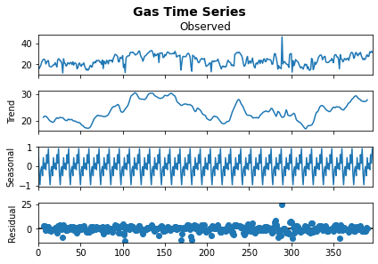

```python
import statsmodels.api as sm

# multiplicative
res = sm.tsa.seasonal_decompose(gas.values,period=12,model="additive")

fig = res.plot()

plt.suptitle("Gas Time Series", y=1.02,weight='bold',size=14)
```

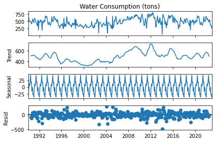

```python
import statsmodels.api as sm
# multiplicative
res = sm.tsa.seasonal_decompose(water,period=12,model="additive")

fig = res.plot()
```

I chose additive instead of multiplicative since there is no exponential increase in the amplitudes over time.

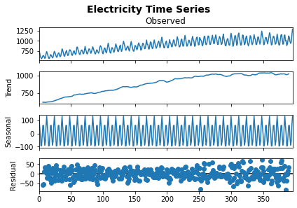

```python
import statsmodels.api as sm
# multiplicative
res = sm.tsa.seasonal_decompose(electricity.values,period=12,model="additive")
fig = res.plot()

plt.suptitle("Electricity Time Series", y=1.02,weight='bold',size=14)
```

# Model selection

```python
#We will find out the required number of AR terms (p) by inspecting the Partial Autocorrelation (PACF) plot.
#The ACF tells how many MA terms (q) are required to remove any autocorrelation in the stationarized series.
```

## Train test split

```python
from sklearn.model_selection import TimeSeriesSplit

N_SPLITS = 5
folds = TimeSeriesSplit(n_splits=N_SPLITS)
```

```python
X = df.index
```

```python
for i, (train_index, valid_index) in enumerate(folds.split(X)):
    X_train, X_valid = X[train_index], X[valid_index]
    ye_train, ye_valid = electricity[train_index], electricity[valid_index]
    yw_train, yw_valid = water[train_index], water[valid_index]
    yg_train, yg_valid = gas[train_index], gas[valid_index]
```

# ARIMA function

p : This value is determined from partial autocorrelation graph

d : This value is determined from the amount of times differencing operation is carried out to make the time series stationary.

q : This value is determined from the autocorrelation graph.

```python
#arima model
import statsmodels.api as sm
from sklearn.metrics import mean_absolute_error, mean_squared_error
import math
from colorama import Fore  # For colored output

def arima_model(y_train, y_valid, order=(2,1,0), forecast_steps=5):
    # Fit ARIMA model
    model = sm.tsa.arima.ARIMA(y_train, order=order)
    fitted_model = model.fit()

    # Forecast with ARIMA
    y_pred = fitted_model.forecast(steps=forecast_steps)

    # Calculate metrics
    score_mae = mean_absolute_error(y_valid, y_pred)
    score_rmse = math.sqrt(mean_squared_error(y_valid, y_pred))
    score_mape = np.mean(np.abs((y_valid - y_pred) / y_valid)) * 100

    # Print model summary and metrics
    print(fitted_model.summary())
    print(Fore.GREEN + 'RMSE: {}'.format(score_rmse))
    print(Fore.GREEN + 'MAE: {}'.format(score_mae))
    print(Fore.GREEN + 'MAPE: {}'.format(score_mape))

    return fitted_model
```

# SARIMA function

There are four seasonal elements that are not part of ARIMA that must be configured; they are: SARIMA(p,d,q)(P,D,Q)SeasonalOrders

P: Seasonal autoregressive order.

D: Seasonal difference order.

Q: Seasonal moving average order.

m: The number of time steps for a single seasonal period. For example, an S of 12 for monthly data suggests a yearly seasonal cycle.

```python
def sarimax_model(y_train, y_valid, order=(2, 1, 0), seasonal_order=(1, 0, 0, 12), forecast_steps=66):
    # Fit SARIMA model
    model = sm.tsa.SARIMAX(y_train, order=order, seasonal_order=seasonal_order)
    fitted_model = model.fit()

    # Forecast with SARIMA
    y_pred = fitted_model.forecast(steps=forecast_steps)

    # Calculate metrics
    score_mae = mean_absolute_error(y_valid, y_pred)
    score_rmse = math.sqrt(mean_squared_error(y_valid, y_pred))
    score_mape = np.mean(np.abs((y_valid - y_pred) / y_valid)) * 100

    # Print model summary and metrics
    print(fitted_model.summary())
    print(Fore.GREEN + 'RMSE: {}'.format(score_rmse))
    print(Fore.GREEN + 'MAE: {}'.format(score_mae))
    print(Fore.GREEN + 'MAPE: {}'.format(score_mape))

    return fitted_model
```

# Model evaluation using auto arima

A model that fits the data very well while using lots of features will be assigned a larger AIC score than a model that uses fewer features to achieve the same goodness-of-fit.

Therefore, we are interested in finding the model that yields the lowest AIC value using auto arima.

The auro_arima function works by conducting differencing tests (i.e., Kwiatkowski–Phillips–Schmidt–Shin, Augmented Dickey-Fuller or Phillips–Perron) to determine the order of differencing, d, and then fitting models within ranges of defined start_p, max_p, start_q, max_q ranges.

```python
from pmdarima.arima import auto_arima

def fit_auto_arima(y_train,d=0,D=0):
    # Use auto_arima to find the best SARIMA model order
    auto_a = auto_arima(y_train, trace=True, error_action='ignore', test='adf',m=12,D=D,d=d,
                        seasonal=True, stepwise=True,
                        suppress_warnings=True)

    # Print the summary of the best SARIMA model
    print(auto_a.summary())

    return auto_a
```

# Rolling forecast

```python
#for arima models
```

```python
def rolling_forecast(train, test,model):
    history = [x for x in train]
    predictions = []
    results = {}
    yhat = model.forecast()[0]

    predictions.append(yhat)
    history.append(test[0])
    for i in range(1, len(test)):
        yhat = model.forecast()[0]
        predictions.append(yhat)
        obs = test[i]
        history.append(obs)
    mse = mean_squared_error(test, predictions)
    mae = mean_absolute_error(test, predictions)
    rmse = math.sqrt(mse)
    predictions = pd.Series(predictions, index=test.index)
    results['predictions'] = predictions
    results['mse'] = mse
    results['rmse'] = rmse
    results['mae'] = mae
    return results
```

# Walk forward forecast

Assess model's performance on new, unseen data.

```python
#for sarima models
```

```python
import statsmodels.api as sm
from math import sqrt

def walk_forecast(train, valid,order=(7,1,0),seasonal_order=(7,1,0,12)):
    history = [x for x in train]
    predictions = list()

    for t in range(len(valid)):
        model = sm.tsa.SARIMAX(history, order=order, seasonal_order=seasonal_order)
        model_fit = model.fit()

        output = model_fit.forecast()
        yhat = output[0]

        predictions.append(yhat)
        obs = valid[t]
        history.append(obs)

        print('predicted=%f, expected=%f' % (yhat, obs))

    rmse = sqrt(mean_squared_error(valid, predictions))
    print('Test RMSE: %.3f' % rmse)

    plt.title('Forecast')
    plt.plot(valid, label='Actual')
    plt.plot(valid.index, predictions, color='red', label='Predicted', ls='--')
    plt.legend()
    plt.show()
```

# Electricity model

Best model

```python
#electricity
optimal_e = fit_auto_arima(ye_train,d=1,D=1)
```

```
Performing stepwise search to minimize aic
 ARIMA(2,1,2)(1,1,1)[12]             : AIC=2891.979, Time=2.32 sec
 ARIMA(0,1,0)(0,1,0)[12]             : AIC=3072.191, Time=0.10 sec
 ARIMA(1,1,0)(1,1,0)[12]             : AIC=3012.062, Time=0.38 sec
 ARIMA(0,1,1)(0,1,1)[12]             : AIC=2934.335, Time=0.57 sec
 ARIMA(2,1,2)(0,1,1)[12]             : AIC=2890.207, Time=1.74 sec
 ARIMA(2,1,2)(0,1,0)[12]             : AIC=inf, Time=0.84 sec
 ARIMA(2,1,2)(0,1,2)[12]             : AIC=2891.849, Time=3.14 sec
 ARIMA(2,1,2)(1,1,0)[12]             : AIC=2949.293, Time=1.93 sec
 ARIMA(2,1,2)(1,1,2)[12]             : AIC=2891.648, Time=5.29 sec
 ARIMA(1,1,2)(0,1,1)[12]             : AIC=2889.710, Time=1.59 sec
 ARIMA(1,1,2)(0,1,0)[12]             : AIC=3000.106, Time=0.53 sec
 ARIMA(1,1,2)(1,1,1)[12]             : AIC=2891.499, Time=2.01 sec
 ARIMA(1,1,2)(0,1,2)[12]             : AIC=2891.375, Time=3.05 sec
 ARIMA(1,1,2)(1,1,0)[12]             : AIC=2951.832, Time=1.20 sec
 ARIMA(1,1,2)(1,1,2)[12]             : AIC=2890.918, Time=4.47 sec
 ARIMA(0,1,2)(0,1,1)[12]             : AIC=2892.344, Time=0.97 sec
 ARIMA(1,1,1)(0,1,1)[12]             : AIC=2890.919, Time=1.24 sec
 ARIMA(1,1,3)(0,1,1)[12]             : AIC=2895.141, Time=1.43 sec
 ARIMA(0,1,3)(0,1,1)[12]             : AIC=2891.499, Time=1.20 sec
 ARIMA(2,1,1)(0,1,1)[12]             : AIC=2890.785, Time=1.71 sec
 ARIMA(2,1,3)(0,1,1)[12]             : AIC=2893.457, Time=3.16 sec
 ARIMA(1,1,2)(0,1,1)[12] intercept   : AIC=2888.138, Time=2.72 sec
 ARIMA(1,1,2)(0,1,0)[12] intercept   : AIC=inf, Time=1.36 sec
 ARIMA(1,1,2)(1,1,1)[12] intercept   : AIC=2889.837, Time=3.61 sec
 ARIMA(1,1,2)(0,1,2)[12] intercept   : AIC=2889.664, Time=4.98 sec
 ARIMA(1,1,2)(1,1,0)[12] intercept   : AIC=inf, Time=2.83 sec
 ARIMA(1,1,2)(1,1,2)[12] intercept   : AIC=2889.105, Time=7.89 sec
 ARIMA(0,1,2)(0,1,1)[12] intercept   : AIC=2892.665, Time=2.67 sec
 ARIMA(1,1,1)(0,1,1)[12] intercept   : AIC=inf, Time=1.26 sec
 ARIMA(2,1,2)(0,1,1)[12] intercept   : AIC=2888.490, Time=4.05 sec
 ARIMA(1,1,3)(0,1,1)[12] intercept   : AIC=2890.281, Time=4.64 sec
 ARIMA(0,1,1)(0,1,1)[12] intercept   : AIC=2936.310, Time=0.75 sec
 ARIMA(0,1,3)(0,1,1)[12] intercept   : AIC=2890.650, Time=3.46 sec
 ARIMA(2,1,1)(0,1,1)[12] intercept   : AIC=2889.107, Time=2.58 sec
 ARIMA(2,1,3)(0,1,1)[12] intercept   : AIC=inf, Time=3.17 sec

Best model:  ARIMA(1,1,2)(0,1,1)[12] intercept
Total fit time: 84.874 seconds
                                      SARIMAX Results
```

[output cut: 11 more lines]

```
intercept     -0.0447      0.021     -2.159      0.031      -0.085      -0.004
ar.L1          0.3472      0.110      3.158      0.002       0.132       0.563
ma.L1         -0.7345      0.110     -6.656      0.000      -0.951      -0.518
ma.L2         -0.2230      0.101     -2.213      0.027      -0.420      -0.026
ma.S.L12      -0.7238      0.041    -17.558      0.000      -0.805      -0.643
sigma2       477.6658     30.500     15.661      0.000     417.886     537.445
===================================================================================
Ljung-Box (L1) (Q):                   0.03   Jarque-Bera (JB):                35.77
Prob(Q):                              0.86   Prob(JB):                         0.00
Heteroskedasticity (H):               2.66   Skew:                            -0.26
Prob(H) (two-sided):                  0.00   Kurtosis:                         4.56
===================================================================================

Warnings:
[1] Covariance matrix calculated using the outer product of gradients (complex-step).
```

## SARIMA

Blue region is set to 95% confidence interval spikes above the blue region suggests that there is a correlation

The autocorrelation function (ACF): It shows the correlation between consumption versus the lagged versions of itself.

The partial autocorrelation (PACF): It shows the correlation between the consumption versus the lagged version excluding the effects of earlier lags, for example, it show the effective influence of the lag 3 in the current temperatures excluding the effects of the lags 1 and 2.

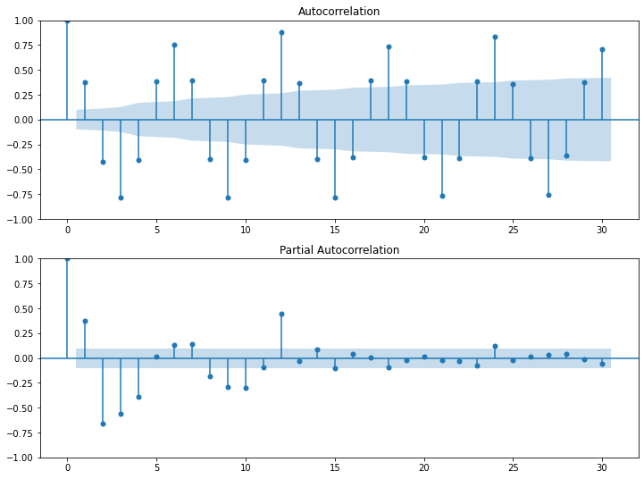

```python
#electricity data
fig = plt.figure(figsize=(12,9))
ax1 = fig.add_subplot(211)
fig = sm.graphics.tsa.plot_acf(df_diff.iloc[1:], lags=30, ax=ax1)
ax2 = fig.add_subplot(212)
fig = sm.graphics.tsa.plot_pacf(df_diff.iloc[1:],lags=30,ax=ax2)
```

A higher order autoregressive term in the data. Use the partial autocorrelation function to determine the order of the autoregressive term. May be cuts off at 3rd lag AR(4)/AR(6)

```python
sarimax_model(ye_train, ye_valid,order=(4,1,0),seasonal_order=(4,1,0,12))
```

```
                                     SARIMAX Results
==========================================================================================
Dep. Variable:      Electricity Consumption (MWh)   No. Observations:                  331
Model:             SARIMAX(4, 1, 0)x(4, 1, 0, 12)   Log Likelihood               -1449.988
Date:                            Fri, 11 Aug 2023   AIC                           2917.977
Time:                                    22:55:18   BIC                           2951.835
Sample:                                01-01-1990   HQIC                          2931.500
                                     - 07-01-2017
Covariance Type:                              opg
==============================================================================
                 coef    std err          z      P>|z|      [0.025      0.975]
------------------------------------------------------------------------------
ar.L1         -0.2761      0.055     -4.995      0.000      -0.384      -0.168
ar.L2         -0.3401      0.061     -5.595      0.000      -0.459      -0.221
ar.L3         -0.1309      0.061     -2.149      0.032      -0.250      -0.012
ar.L4         -0.1660      0.058     -2.841      0.004      -0.280      -0.051
ar.S.L12      -0.6660      0.054    -12.427      0.000      -0.771      -0.561
ar.S.L24      -0.5700      0.063     -9.063      0.000      -0.693      -0.447
ar.S.L36      -0.3380      0.061     -5.556      0.000      -0.457      -0.219
ar.S.L48      -0.1503      0.062     -2.437      0.015      -0.271      -0.029
sigma2       519.5948     34.328     15.136      0.000     452.313     586.876
===================================================================================
Ljung-Box (L1) (Q):                   0.32   Jarque-Bera (JB):                49.70
Prob(Q):                              0.57   Prob(JB):                         0.00
Heteroskedasticity (H):               2.74   Skew:                            -0.27
Prob(H) (two-sided):                  0.00   Kurtosis:                         4.86
===================================================================================

Warnings:
[1] Covariance matrix calculated using the outer product of gradients (complex-step).
RMSE: 34.75158874375108
MAE: 26.389745151723297
MAPE: 2.5107101510360943
```

```
<statsmodels.tsa.statespace.sarimax.SARIMAXResultsWrapper at 0x23a01652f40>
```

### Best model

```python
elmodel=sarimax_model(ye_train, ye_valid,order=(7,1,0),seasonal_order=(7,1,0,12))
```

```
                                     SARIMAX Results
==========================================================================================
Dep. Variable:      Electricity Consumption (MWh)   No. Observations:                  331
Model:             SARIMAX(7, 1, 0)x(7, 1, 0, 12)   Log Likelihood               -1439.788
Date:                            Fri, 11 Aug 2023   AIC                           2909.576
Time:                                    22:55:33   BIC                           2966.007
Sample:                                01-01-1990   HQIC                          2932.115
                                     - 07-01-2017
Covariance Type:                              opg
==============================================================================
                 coef    std err          z      P>|z|      [0.025      0.975]
------------------------------------------------------------------------------
ar.L1         -0.3165      0.060     -5.298      0.000      -0.434      -0.199
ar.L2         -0.4009      0.062     -6.433      0.000      -0.523      -0.279
ar.L3         -0.2508      0.071     -3.540      0.000      -0.390      -0.112
ar.L4         -0.2616      0.069     -3.817      0.000      -0.396      -0.127
ar.L5         -0.2244      0.064     -3.501      0.000      -0.350      -0.099
ar.L6         -0.0386      0.059     -0.657      0.511      -0.154       0.077
ar.L7         -0.0456      0.058     -0.784      0.433      -0.160       0.068
ar.S.L12      -0.7129      0.058    -12.361      0.000      -0.826      -0.600
ar.S.L24      -0.6637      0.071     -9.344      0.000      -0.803      -0.524
ar.S.L36      -0.4684      0.085     -5.538      0.000      -0.634      -0.303
ar.S.L48      -0.3590      0.088     -4.093      0.000      -0.531      -0.187
ar.S.L60      -0.2374      0.088     -2.699      0.007      -0.410      -0.065
ar.S.L72      -0.1071      0.089     -1.199      0.231      -0.282       0.068
ar.S.L84      -0.0634      0.057     -1.104      0.269      -0.176       0.049
sigma2       483.2869     35.219     13.722      0.000     414.260     552.314
===================================================================================
Ljung-Box (L1) (Q):                   0.02   Jarque-Bera (JB):                42.62
Prob(Q):                              0.89   Prob(JB):                         0.00
Heteroskedasticity (H):               2.57   Skew:                            -0.25
Prob(H) (two-sided):                  0.00   Kurtosis:                         4.72
===================================================================================

Warnings:
[1] Covariance matrix calculated using the outer product of gradients (complex-step).
RMSE: 34.25839888644265
MAE: 24.294535692651454
MAPE: 2.27790923094688
```

Because the p-value of the Ljung-Box test is greater than 0.05, we cannot reject the null hypothesis that the residuals are independent.

## ARIMA

Not needed as the acf displays seasonality.

```python
# arima_model(ye_train, ye_valid, order=(4,1,0), forecast_steps=66)
```

## Evaluation

A good forecasting method will have minimal information left in the residuals if any.

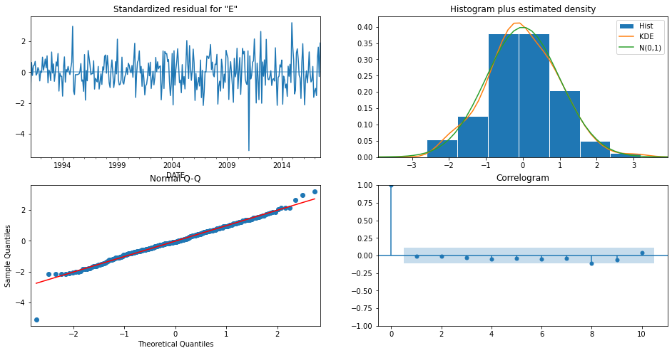

```python
elmodel.plot_diagnostics(figsize=(16,8))
plt.show()
```

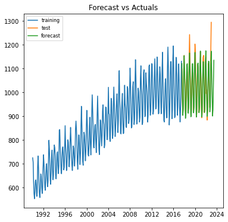

```python
extended_index = pd.date_range(start=yg_valid.index[0], periods=72,freq='MS')


fc = elmodel.forecast(72,alpha=0.05)

# Step 3: Convert the forecasted values to Pandas Series
fc_series = pd.Series(fc, index=extended_index)

# Step 4: Plot the results
plt.figure(figsize=(6, 6))
plt.plot(ye_train, label='training')
plt.plot(ye_valid,label='test')
plt.plot(fc_series, label='forecast')
plt.title('Forecast vs Actuals')
plt.legend(loc='upper left', fontsize=8)
plt.show()
```

```
predicted=1120.680297, expected=1098.600000
predicted=963.196547, expected=967.400000
predicted=898.415693, expected=903.800000
predicted=927.716572, expected=943.400000
predicted=1092.400650, expected=1052.700000
predicted=1131.570362, expected=1155.000000
predicted=1078.064613, expected=1067.300000
predicted=969.671546, expected=1029.900000
predicted=921.001820, expected=910.100000
predicted=926.906649, expected=909.600000
predicted=1014.992765, expected=1007.000000
predicted=1107.704077, expected=1101.500000
predicted=1103.465874, expected=1081.800000
predicted=980.351437, expected=992.800000
predicted=915.799643, expected=917.900000
predicted=937.875239, expected=972.900000
predicted=1115.926153, expected=1134.700000
predicted=1185.479839, expected=1242.500000
predicted=1122.110539, expected=1128.800000
predicted=1043.420711, expected=1047.600000
predicted=933.242340, expected=902.900000
predicted=925.426928, expected=921.300000
predicted=1042.506792, expected=1018.800000
predicted=1128.618816, expected=1085.500000
predicted=1098.513290, expected=1081.900000
predicted=989.424071, expected=1004.200000
predicted=922.862063, expected=923.800000
predicted=956.225017, expected=997.000000
predicted=1149.774585, expected=1093.500000
predicted=1173.315262, expected=1202.700000
predicted=1101.205587, expected=1163.800000
predicted=1050.938652, expected=1044.700000
predicted=918.986661, expected=897.500000
predicted=937.504211, expected=910.900000
predicted=1019.166453, expected=1026.500000
predicted=1121.972429, expected=1116.400000
predicted=1120.755995, expected=1105.900000
predicted=1000.376033, expected=1019.200000
predicted=938.481277, expected=916.000000
predicted=960.836215, expected=930.600000
```

[output cut: 12 more lines]

```
predicted=1078.126248, expected=1127.700000
predicted=1214.823631, expected=1148.500000
predicted=1060.569251, expected=994.900000
predicted=944.365693, expected=1010.400000
predicted=919.612872, expected=883.500000
predicted=889.081648, expected=920.800000
predicted=1037.439112, expected=1021.500000
predicted=1112.584038, expected=1121.500000
predicted=1106.293999, expected=1089.300000
predicted=985.801608, expected=986.200000
predicted=898.499296, expected=936.100000
predicted=965.284750, expected=973.400000
predicted=1117.754852, expected=1147.200000
predicted=1204.349705, expected=1294.000000
Test RMSE: 32.552
```

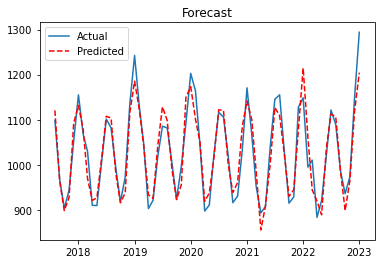

```python
walk_forecast(ye_train, ye_valid)
```

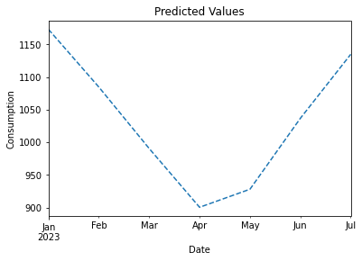

```python
#Forecast for next 6 months
df_pred = elmodel.predict(start='2017-08-01', end='2023-07-01')
df_pred['2023-01-01':'2023-07-01'].plot(ls='--')

# Set title, xlabel, and ylabel for the plot
plt.title('Predicted Values')
plt.xlabel('Date')
plt.ylabel('Consumption')

plt.show()
```

Electricity consumption has a steep drop from January to April.

Increases slightly from April to May before a steeper increasing from May to July.

# Gas model

Singapore relies on imported natural gas for about 95 per cent of its electricity needs, and prices here have been increasing since September last year, in tandem with gas prices rising worldwide.

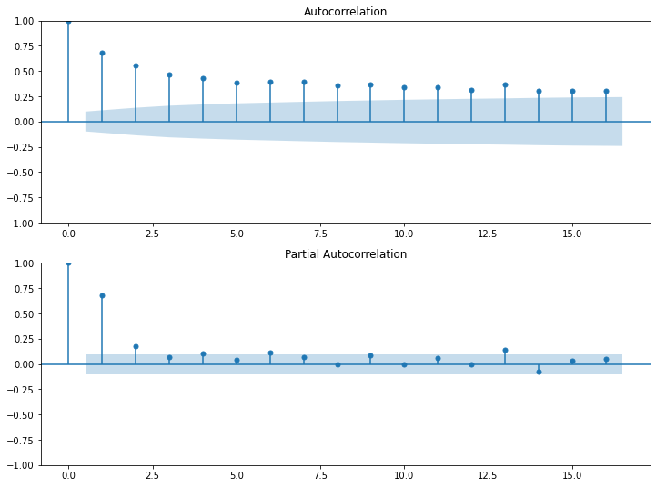

```python
#gas
fig = plt.figure(figsize=(12,9))
ax1 = fig.add_subplot(211)
fig = sm.graphics.tsa.plot_acf(df['Gas Consumption (tons)'], lags=16, ax=ax1)
ax2 = fig.add_subplot(212)
fig = sm.graphics.tsa.plot_pacf(df['Gas Consumption (tons)'],lags=16,ax=ax2)
```

The ACF plot gradually tails towards zero while the PACF drops under the confidence interval after the second lag, this is an AR signature with a parameter of 2, so this is an AR(2) model.

```python
#gas
optimal_g= fit_auto_arima(yg_train)
```

```
Performing stepwise search to minimize aic
 ARIMA(2,0,2)(1,0,1)[12] intercept   : AIC=inf, Time=2.43 sec
 ARIMA(0,0,0)(0,0,0)[12] intercept   : AIC=2008.533, Time=0.07 sec
 ARIMA(1,0,0)(1,0,0)[12] intercept   : AIC=1816.389, Time=0.86 sec
 ARIMA(0,0,1)(0,0,1)[12] intercept   : AIC=1892.448, Time=0.41 sec
 ARIMA(0,0,0)(0,0,0)[12]             : AIC=3039.067, Time=0.04 sec
 ARIMA(1,0,0)(0,0,0)[12] intercept   : AIC=1815.447, Time=0.11 sec
 ARIMA(1,0,0)(0,0,1)[12] intercept   : AIC=1816.576, Time=0.52 sec
 ARIMA(1,0,0)(1,0,1)[12] intercept   : AIC=1819.441, Time=1.34 sec
 ARIMA(2,0,0)(0,0,0)[12] intercept   : AIC=1805.941, Time=0.32 sec
 ARIMA(2,0,0)(1,0,0)[12] intercept   : AIC=1807.075, Time=1.19 sec
 ARIMA(2,0,0)(0,0,1)[12] intercept   : AIC=1807.173, Time=0.60 sec
 ARIMA(2,0,0)(1,0,1)[12] intercept   : AIC=1809.144, Time=2.20 sec
 ARIMA(3,0,0)(0,0,0)[12] intercept   : AIC=1806.337, Time=0.45 sec
 ARIMA(2,0,1)(0,0,0)[12] intercept   : AIC=1792.601, Time=1.23 sec
 ARIMA(2,0,1)(1,0,0)[12] intercept   : AIC=1797.197, Time=2.12 sec
 ARIMA(2,0,1)(0,0,1)[12] intercept   : AIC=1792.223, Time=1.99 sec
 ARIMA(2,0,1)(1,0,1)[12] intercept   : AIC=1812.679, Time=2.57 sec
 ARIMA(2,0,1)(0,0,2)[12] intercept   : AIC=1793.113, Time=4.17 sec
 ARIMA(2,0,1)(1,0,2)[12] intercept   : AIC=1812.168, Time=4.85 sec
 ARIMA(1,0,1)(0,0,1)[12] intercept   : AIC=1803.355, Time=0.88 sec
 ARIMA(3,0,1)(0,0,1)[12] intercept   : AIC=1796.040, Time=2.43 sec
 ARIMA(2,0,2)(0,0,1)[12] intercept   : AIC=1795.470, Time=2.41 sec
 ARIMA(1,0,2)(0,0,1)[12] intercept   : AIC=1797.333, Time=2.31 sec
 ARIMA(3,0,0)(0,0,1)[12] intercept   : AIC=1807.189, Time=0.96 sec
 ARIMA(3,0,2)(0,0,1)[12] intercept   : AIC=1794.494, Time=2.68 sec
 ARIMA(2,0,1)(0,0,1)[12]             : AIC=1794.654, Time=0.70 sec

Best model:  ARIMA(2,0,1)(0,0,1)[12] intercept
Total fit time: 39.862 seconds
                                     SARIMAX Results
==========================================================================================
Dep. Variable:                                  y   No. Observations:                  331
Model:             SARIMAX(2, 0, 1)x(0, 0, 1, 12)   Log Likelihood                -890.111
Date:                            Fri, 11 Aug 2023   AIC                           1792.223
Time:                                    23:14:18   BIC                           1815.036
Sample:                                01-01-1990   HQIC                          1801.322
                                     - 07-01-2017
Covariance Type:                              opg
==============================================================================
                 coef    std err          z      P>|z|      [0.025      0.975]
------------------------------------------------------------------------------
intercept      0.5428      0.391      1.387      0.165      -0.224       1.310
ar.L1          1.3367      0.074     18.180      0.000       1.193       1.481
ar.L2         -0.3608      0.061     -5.932      0.000      -0.480      -0.242
ma.L1         -0.8362      0.074    -11.283      0.000      -0.981      -0.691
ma.S.L12      -0.0883      0.034     -2.592      0.010      -0.155      -0.022
sigma2        12.4633      0.570     21.873      0.000      11.346      13.580
===================================================================================
Ljung-Box (L1) (Q):                   0.00   Jarque-Bera (JB):              1730.48
Prob(Q):                              0.97   Prob(JB):                         0.00
Heteroskedasticity (H):               2.24   Skew:                             0.76
Prob(H) (two-sided):                  0.00   Kurtosis:                        14.10
===================================================================================

Warnings:
[1] Covariance matrix calculated using the outer product of gradients (complex-step).
```

## SARIMAX

```python
sarimax_model(yg_train, yg_valid, order=(2,0,0), seasonal_order=(2, 0, 0, 12), forecast_steps=66)
```

```
                                     SARIMAX Results
==========================================================================================
Dep. Variable:             Gas Consumption (tons)   No. Observations:                  331
Model:             SARIMAX(2, 0, 0)x(2, 0, 0, 12)   Log Likelihood                -916.218
Date:                            Fri, 11 Aug 2023   AIC                           1842.436
Time:                                    23:14:19   BIC                           1861.447
Sample:                                01-01-1990   HQIC                          1850.019
                                     - 07-01-2017
Covariance Type:                              opg
==============================================================================
                 coef    std err          z      P>|z|      [0.025      0.975]
------------------------------------------------------------------------------
ar.L1          0.6879      0.027     25.100      0.000       0.634       0.742
ar.L2          0.3026      0.030     10.206      0.000       0.244       0.361
ar.S.L12      -0.0942      0.032     -2.904      0.004      -0.158      -0.031
ar.S.L24       0.0100      0.076      0.131      0.895      -0.139       0.160
sigma2        14.6845      0.464     31.621      0.000      13.774      15.595
===================================================================================
Ljung-Box (L1) (Q):                   1.04   Jarque-Bera (JB):              2413.74
Prob(Q):                              0.31   Prob(JB):                         0.00
Heteroskedasticity (H):               2.47   Skew:                             1.06
Prob(H) (two-sided):                  0.00   Kurtosis:                        16.06
===================================================================================

Warnings:
[1] Covariance matrix calculated using the outer product of gradients (complex-step).
RMSE: 11.146437359138538
MAE: 10.156291868968292
MAPE: 36.99296820250882
```

```
<statsmodels.tsa.statespace.sarimax.SARIMAXResultsWrapper at 0x23a01db3400>
```

## ARIMA

ACF plot may also be interpreted as tails down to zero so MA may also be 0

```python
arima_model(yg_train, yg_valid, order=(2, 0, 1), forecast_steps=66)
```

```
                                 SARIMAX Results
==================================================================================
Dep. Variable:     Gas Consumption (tons)   No. Observations:                  331
Model:                     ARIMA(2, 0, 1)   Log Likelihood                -891.161
Date:                    Fri, 11 Aug 2023   AIC                           1792.322
Time:                            23:14:20   BIC                           1811.332
Sample:                        01-01-1990   HQIC                          1799.904
                             - 07-01-2017
Covariance Type:                      opg
==============================================================================
                 coef    std err          z      P>|z|      [0.025      0.975]
------------------------------------------------------------------------------
const         22.5268      1.895     11.886      0.000      18.812      26.241
ar.L1          1.3839      0.057     24.460      0.000       1.273       1.495
ar.L2         -0.3956      0.049     -8.008      0.000      -0.492      -0.299
ma.L1         -0.8861      0.051    -17.428      0.000      -0.986      -0.786
sigma2        12.7264      0.546     23.322      0.000      11.657      13.796
===================================================================================
Ljung-Box (L1) (Q):                   0.10   Jarque-Bera (JB):              1834.23
Prob(Q):                              0.75   Prob(JB):                         0.00
Heteroskedasticity (H):               2.30   Skew:                             0.69
Prob(H) (two-sided):                  0.00   Kurtosis:                        14.45
===================================================================================

Warnings:
[1] Covariance matrix calculated using the outer product of gradients (complex-step).
RMSE: 6.174422278599573
MAE: 5.545494850950408
MAPE: 20.16086737736496
```

```
<statsmodels.tsa.arima.model.ARIMAResultsWrapper at 0x23a22a3ebe0>
```

### Best model

```python
gasmodel=arima_model(yg_train, yg_valid, order=(2, 0, 0), forecast_steps=66)
```

```
                                 SARIMAX Results
==================================================================================
Dep. Variable:     Gas Consumption (tons)   No. Observations:                  331
Model:                     ARIMA(2, 0, 0)   Log Likelihood                -898.970
Date:                    Fri, 11 Aug 2023   AIC                           1805.941
Time:                            23:14:20   BIC                           1821.149
Sample:                        01-01-1990   HQIC                          1812.006
                             - 07-01-2017
Covariance Type:                      opg
==============================================================================
                 coef    std err          z      P>|z|      [0.025      0.975]
------------------------------------------------------------------------------
const         23.1677      0.762     30.396      0.000      21.674      24.662
ar.L1          0.5441      0.035     15.372      0.000       0.475       0.614
ar.L2          0.1850      0.045      4.145      0.000       0.098       0.273
sigma2        13.3557      0.599     22.301      0.000      12.182      14.529
===================================================================================
Ljung-Box (L1) (Q):                   0.05   Jarque-Bera (JB):              1999.02
Prob(Q):                              0.82   Prob(JB):                         0.00
Heteroskedasticity (H):               2.35   Skew:                             0.85
Prob(H) (two-sided):                  0.00   Kurtosis:                        14.92
===================================================================================

Warnings:
[1] Covariance matrix calculated using the outer product of gradients (complex-step).
RMSE: 4.68264400527545
MAE: 3.913170273715229
MAPE: 14.168398139403763
```

AIC and MAPE fares worse for the SARIMA model hence we choose the ARIMA model.

Despite the auto arima having a lower AIC, upon testing the parameters, the model had higher MAPE than the model with our parameters